# Data prep: Rubenstein et al. 2023

# Summary

Read in the various data files to see what they contain and how they relate to one another

# Data sources

- Rubenstein et al. (2023). Climate change and the global redistribution of biodiversity: Substantial variation in empirical support for expected range shifts. Environmental Evidence, 12(1), 7. https://doi.org/10.1186/s13750-023-00296-0
- CoRE (Contractions or Range Expansions) Database: Global Database of Species Range Shifts from 1802-2019: Data downloaded from https://www.sciencebase.gov/catalog/item/64147d6fd34eb496d1ceb497

# Methods

```r
library(tidyverse)
library(here)
library(DBI)

library(sf)
```

## Set up data folders

See README.md for details on extraction into proper destination directories.

## Read in .csvs individually

Use `janitor::clean_names()` to standardize variable names to `snake_case`.

### Climate variables

```r
climate_df <- read_csv(here('_raw_data/db_range_shifts', 'Climate.Variables.csv')) %>%
  janitor::clean_names() %>%
  rename(climate_code = reference_number)
DT::datatable(climate_df)
```

|  | climate_code | variable_description |
| --- | --- | --- |
| 1 | A1 | Annual mean temperature |
| 2 | A2 | Annual mean diurnal range |
| 3 | A3 | Max temperature of warmest month (annual max) |
| 4 | A4 | Min temperature of coldest month (annual min) |
| 5 | A5 | Mean temperature of warmest month |
| 6 | A6 | Mean temperature of coldest month |
| 7 | A7 | Mean temperature of the warmest quarter (summer) |
| 8 | A8 | Mean temperature of the coldest quarter (winter) |
| 9 | A9 | Maximum temperature of warmest quarter (summer) |
| 10 | A10 | Minimum temperature of coldest quarter (winter) |

[output cut: 96 more lines]

### Paper details

These associate a `paperid` with variables about each paper: `author`, `title`, `year`, `journal`, `doi`. The dataframe is 315 observations across the six variables.

```r
paperid_df <- read_csv(here('_raw_data/db_range_shifts', 'PaperID.csv')) %>%
  janitor::clean_names()
head(paperid_df)
```

```
# A tibble: 6 × 6
  paperid author            title                             year journal doi
    <dbl> <chr>             <chr>                            <dbl> <chr>   <chr>
1       1 Currie et al      Climate change is not a major d…  2017 Global… 10.1…
2       2 Kelly and Goulden Rapid shifts in plant distribut…  2008 PNAS    10.1…
3       5 Morelli et al     Anthropogenic refugia ameliorat…  2012 Procee… 10.1…
4       6 Sultaire et al    Climate change surpasses land-u…  2016 Procee… 10.1…
5       7 Perry et al       Climate change and distribution…  2005 Science 10.1…
6       8 Lenoir et al      A significant upward shift in p…  2008 Science 10.1…
```

### Range shift details

This dataframe has a `paperid` column that corresponds to the `paperid` column in the paper details dataframe.

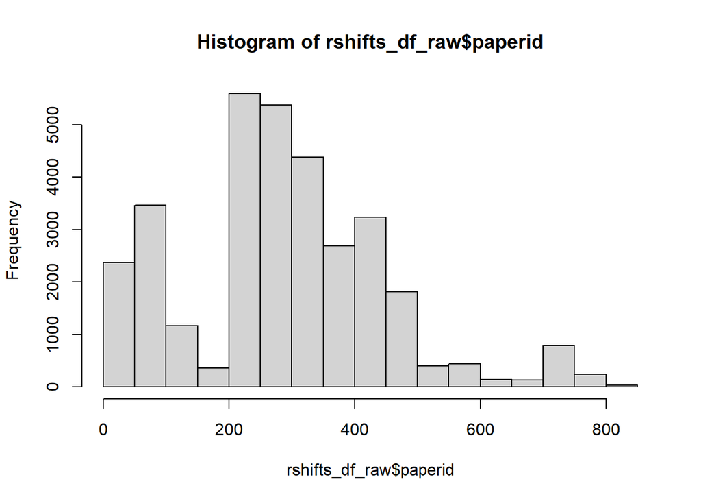

```r
rshifts_df_raw <- read_csv(here('_raw_data/db_range_shifts', 'Range.Shifts.csv')) %>%
  janitor::clean_names()
# names(rshifts_df)
# x <- inner_join(rshifts_df, paperid_df, by = 'paperid')
# nrow(x) == nrow(rshifts_df)
### TRUE - all rshifts_df rows are accounted for
hist(rshifts_df_raw$paperid)
```

The `temp` column seems to contain codes related to `climate_df$reference_number` for both `A` and `B`, with multiple values in some rows separated by commas (e.g., `B9, B1`). Similar for the `precip` column for codes `C`. These are then associated with notes about Additional details on species name/taxonomic information, hemisphere, CASC.

## Split out range shifts dataframe

The range shifts dataframe contains a lot of repeated information that could better fit into relational tables. Identify redundant info and split out.

### Convert `speriod` to integer

The `speriod` variable is generally in `P#` format; the `P` doesn’t really carry any info but coerces the column into character instead of integer, which takes a lot more space.

```r
# rshifts_df_raw$speriod %>% table() ### some bare numbers, mostly P# format
  #   1    10    11    12    13    14    15    16     2     3     4     5
  #   1     1     1     1     1     1     1     1     1     1     1     1
  #   6     7     8     9    P1   P10   P11   P12   P13   P14   P15   P16
  #   1     1     1     1 27862     5     5     5     5     5     5     5
  # P17   P18   P19    P2   P20   P21   P22   P23   P24    P3    P4    P5
  #   5     5     5  3222     5     5     1     1     1   693   292   105
  #  P6    P7    P8    P9
  # 134   166    56    25
# x <- rshifts_df_raw %>%
#   group_by(paperid, polygon_name, ecotype) %>%
#   filter(any(!str_detect(speriod, 'P')))
### the bare numbers are all associated with one polygon/paper - data entry mistake?

rshifts_df <- rshifts_df_raw %>%
  mutate(speriod = str_extract(speriod, '[0-9]+') %>% as.integer())
```

### Species per paper

Most papers contain information on multiple species.

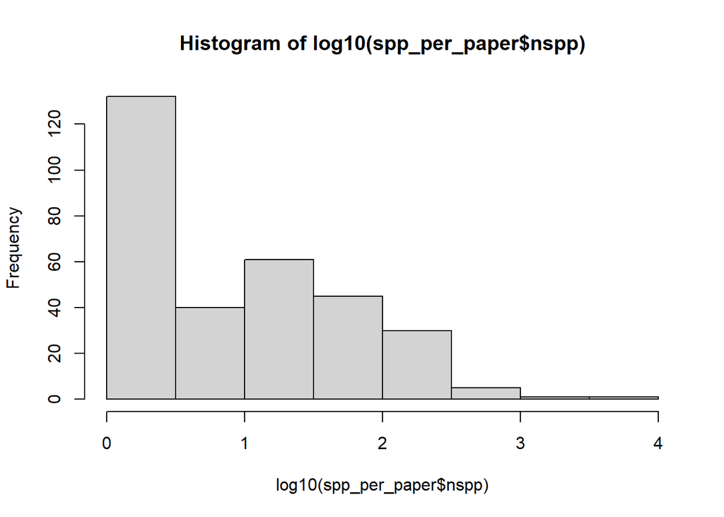

```r
spp_per_paper <- rshifts_df %>%
  group_by(paperid) %>%
  summarize(nspp = n_distinct(species))

hist(log10(spp_per_paper$nspp))
```

### Polygons per paper

Each of 315 papers has one or more polygons associated with it; it appears that each of 463 polygons is associated with exactly one paper, and the polygon name is perhaps prefixed with that paper ID (extra redundancy…).

```r
polys_per_paper <- rshifts_df %>%
  select(paperid, polygon_name) %>%
  distinct() %>%
  mutate(check_id = str_extract(polygon_name, '^[0-9]+') %>% as.numeric()) %>%
  mutate(checks_out = check_id == paperid)
```

```r
poly_attrs_per_paper <- rshifts_df %>%
  # select(paperid, polygon_name, speriod:habtype) %>%
  distinct() %>%
  group_by(paperid, polygon_name, speriod, ecotype) %>%
  summarize(across(everything(), ~ n_distinct(.x)),
            .groups = 'drop')

single_attrs <- poly_attrs_per_paper %>%
  pivot_longer(cols = c(-paperid, -polygon_name, -speriod, -ecotype), names_to = 'var', values_to = 'val') %>%
  mutate(var = fct_inorder(var)) %>%
  group_by(var) %>%
  summarize(max_values = max(val), .groups = 'drop') %>%
  filter(max_values == 1)

polygon_vars <- as.character(single_attrs$var)
```

```r
polygon_keys <- c('polygon_name', 'speriod', 'ecotype')
poly_attrs_climate_df <- rshifts_df %>%
  select(all_of(polygon_keys), all_of(polygon_vars)) %>%
  distinct() %>%
  ### gather the two climate columns into a single column and separate
  ### multiple entries into individual observations
  pivot_longer(cols = c(temp, precip), names_to = 'climate_variable', values_to = 'climate_code') %>%
  mutate(climate_code = str_split(climate_code, pattern = ', *')) %>%
  unnest(climate_code) %>%
  ### fix malformed entries
  mutate(climate_code = str_remove_all(climate_code, ' ')) %>%
  filter(!is.na(climate_code) & climate_code != '') %>%
  mutate(climate_code = ifelse(climate_code == '19', 'C19', climate_code)) %>%
  ### drop climate_variable, as redundant (info contained in climate_code)
  select(-climate_variable) %>%
  distinct()

poly_clim_df <- poly_attrs_climate_df %>%
  select(polygon_name, climate_code) %>%
  distinct()

poly_attrs_df <- poly_attrs_climate_df %>%
  select(-climate_code) %>%
  distinct()
```

### Distinct species included

Separate out species taxonomic info from the climate and shift info using `species` as key. Note, common name `cname` is highly variable and not 1:1 match to `species` in either direction, so doing a little clean up then combining all cnames into a single row. Each species, in each polygon, is associated with one value for `casc` and one value for `data_source_title`, but multiple values for climate-related observations including `dim`, `obsvt`, etc.

```r
rshifts_df <- rshifts_df %>%
  ### some weird characters in there:
  mutate(sciname = str_remove_all(sciname, '�'))

sciname_comname_fix <- rshifts_df %>%
  select(sciname, cname) %>%
  distinct() %>%
  filter(!is.na(cname) & cname != 'n/a') %>%
  mutate(cname = str_to_sentence(cname) %>%
           stringi::stri_trans_general('Latin-ASCII'),  ### drop diacritics
         cname = str_remove_all(cname, '�'),
         cname = str_replace_all(cname, '-', ' ')) %>%
  distinct() %>%
  group_by(sciname) %>%
  mutate(cname = paste(cname, collapse = ';')) %>%
  ungroup() %>%
  distinct()

x <- sciname_comname_fix %>%
  group_by(sciname) %>%
  filter(n_distinct(cname) > 1)
```

```r
tax_vars <- c('cname', 'tax', 'kingdom', 'phylum', 'class', 'order', 'family', 'genus', 'species', 'k2', 't2')
tax_keys <- c('sciname')

distinct_spp <- rshifts_df %>%
  select(-cname) %>%
  left_join(sciname_comname_fix, by = 'sciname') %>%
  select(all_of(tax_keys), all_of(tax_vars)) %>%
  distinct() %>%
  ### one spp name with two taxa - it is arachnid ("other"), NOT insect
  filter(!(tax == 'insect' & species == 'Ixodes ricinus'))

spp_poly_df <- rshifts_df %>%
  select(all_of(tax_keys), all_of(polygon_keys), casc, data_source_title) %>%
  distinct()
### check single values for casc and data_source_title:
# x <- spp_poly_df %>%
#   group_by(sciname, polygon_name, speriod, ecotype) %>%
#   summarize(ncasc = n_distinct(casc), ndata = n_distinct(data_source_title)) %>%
#   filter(ncasc > 1 | ndata > 1)

# spp_comname <- rshifts_df %>%
#   select(species, cname) %>%
#   mutate(cname = str_to_sentence(cname)) %>%
#   filter(!is.na(cname) & cname != 'N/a') %>%
#   distinct()
# x <- spp_comname %>% group_by(species) %>% filter(n() > 1)

range_shifts_clean <- rshifts_df %>%
  select(-all_of(tax_vars), -all_of(polygon_vars), -casc, -data_source_title) %>%
  distinct()

x <- range_shifts_clean %>%
  group_by(sciname, polygon_name, speriod, ecotype) %>%
  summarize(across(everything(), ~ n_distinct(.x)))
```

## Put tables in a SQL database

The range shifts data still contains a ton of information in all those columns; but if there is a lot of redundancy it might make sense to put into separate related tables.

```r
db_file <- here('_raw_data/db_range_shifts.sqlite')

if(file.exists(db_file)) unlink(db_file)

mydb <- dbConnect(RSQLite::SQLite(), db_file)
dbWriteTable(mydb, 'paper_id', paperid_df)
dbWriteTable(mydb, 'climate_variables', climate_df)
dbWriteTable(mydb, 'tax_names', distinct_spp)
dbWriteTable(mydb, 'species_polygons', spp_poly_df)
dbWriteTable(mydb, 'polygon_attrs', poly_attrs_df)
dbWriteTable(mydb, 'polygon_climate', poly_clim_df)
dbWriteTable(mydb, 'range_shifts', range_shifts_clean)

dbDisconnect(mydb)
```

## Using SQL database

Check join columns in R:

```r
join_test <- range_shifts_clean %>%
  left_join(poly_attrs_df, by = c('polygon_name', 'speriod', 'ecotype')) %>%
  left_join(poly_clim_df, by = 'polygon_name', relationship = 'many-to-many') %>%
  left_join(spp_poly_df, by = c('polygon_name', 'speriod', 'ecotype', 'sciname'))
```

Create the connection using `DBI::dbConnect()`

```r
db_file <- here('_raw_data/db_range_shifts.sqlite')
mydb <- dbConnect(RSQLite::SQLite(), db_file)
```

```sql
SELECT * FROM range_shifts as rs
LEFT JOIN species_polygons as sp
  USING (polygon_name, speriod, ecotype, sciname)
LEFT JOIN polygon_attrs as pa
  USING (polygon_name, speriod, ecotype)
LEFT JOIN polygon_climate as pc
  USING (polygon_name)
LEFT JOIN climate_variables as cv
  USING (climate_code)
```

```r
dbDisconnect(mydb)


check <- anti_join(join_test, df_from_sql,
                   by = c('polygon_name', 'paperid', 'speriod', 'ecotype', 'sciname'))

if(nrow(check) > 0) stop('The R join test and SQL join test do not match up!')
```